# SEI/CADE - 0893793 - Voto Requerimento de TCC

**Ministério da Justiça e Segurança Pública - MJSP**

**Conselho Administrativo de Defesa Econômica - CADE**

SEPN 515, Conjunto D, Lote 4, Edifício Carlos Taurisano, - Bairro Asa Norte, Brasília/DF, CEP 70770-504  
Telefone: (61) 3221-8475 - www.cade.gov.br

**Requerimento nº 08700.005718/2020-69 (Apartado Restrito nº 08700.005737/2020-95)**

**Requerente:** Sistema Informática COM. IMP. EXP. LTDA.

**Advogadas(os):** Paula Simonetti Junqueira de Andrade Amaral, Vitória Oliveira, Thomas Benes Felsberg e outros.

**Relator**: Conselheiro Maurício Oscar Bandeira Maia

VOTO VOGAL - CONSELHEIRO SÉRGIO COSTA RAVAGNANI

VERSÃO PÚBLICA

**voto**

Com as devidas vênias, divirjo do entendimento do Conselheiro Relator e acompanho a divergência inaugurada pela Conselheira Paula Azevedo, pelos fundamentos a seguir expostos.

**I – ANÁLISE DOS REQUISITOS LEGAIS VINCULADOS**

**a) Da contribuição pecuniária ao Fundo de Direitos Difusos (“FDD”) prevista para a empresa**

Como se extrai da análise das informações contidas no balanço do ano 2011 da Requerente (SEI 0875652), o faturamento bruto no ramo de atividade empresarial nº 97 da Resolução nº 3, de 29 de maio de 2012 (“Resolução CADE nº 3/2012”) (comércio varejista), foi de [**ACESSO RESTRITO AO CADE E À REQUERENTE]**. Por outro lado, na memória de cálculo da contribuição pecuniária da empresa contida no Anexo I da proposta de TCC em julgamento, o cálculo da multa esperada da empresa foi realizado a partir do emprego **do faturamento bruto no ano 2011 no mercado do produto afetado, qual seja, lousa interativa digital****, no valor de** [**ACESSO RESTRITO AO CADE E À REQUERENTE]****.**

Não existe, portanto, razão para que seja utilizado o faturamento bruto obtido com a comercialização do produto afetado como base de cálculo da multa esperada da empresa, ademais porque, no caso em julgamento, este valor é drasticamente menor do que o valor do faturamento bruto obtido pela Requerente no ramo de atividade empresarial.

Como me manifestei no voto proferido no PA nº 08012.005324/2012-59, os parâmetros para aplicação de multa por infração à ordem econômica para empresas estão previstos no inc. I do art. 37 da Lei nº 12.529/2011, conforme dispositivo reproduzido abaixo:

Art. 37. A prática de infração da ordem econômica sujeita os responsáveis às seguintes penas:

I - no caso de empresa, multa de 0,1% (um décimo por cento) a 20% (vinte por cento) do valor do faturamento bruto da empresa, grupo ou conglomerado obtido, no último exercício anterior à instauração do processo administrativo, no ramo de atividade empresarial em que ocorreu a infração, a qual nunca será inferior à vantagem auferida, quando for possível sua estimação;

É dever da autoridade verificar a viabilidade de estimar o valor da vantagem auferida pela empresa por meio da infração cometida, sendo este o valor mínimo da multa. No caso da proposta de TCC em julgamento, verifica-se que não há elementos suficientes nos autos do PA nº 08012.007043/2010-79 para estimar a vantagem auferida, de tal forma que deve ser aplicado o critério sucessivo de aplicação da alíquota de 0,1% a 20% sobre o valor do faturamento bruto da empresa no ramo de atividade empresarial em que ocorreu a infração no último exercício anterior à instauração do processo administrativo.

A lei estabelece que a base de cálculo sobre a qual incide a alíquota é fixa e compreende parâmetros nela estabelecidos quanto aos seguintes aspectos: (i) tipo de faturamento (bruto); (ii) tempo (ano anterior à instauração do PA); e (iii) abrangência (ramo de atividade empresarial em que ocorreu a infração). A respeito deste último parâmetro, o Cade editou a lista com a definição dos ramos de atividades empresariais para fins de aplicação do art. 37 da Lei nº 12.529/2011 por meio da Resolução CADE nº 3/2012.

A Lei nº 12.529/11 estabelece no § 2º do art. 37, uma alternativa à dimensão da base de cálculo quando o valor do faturamento no ramo de atividade empresarial não estiver disponível ou for apresentado de forma incompleta e/ou não demonstrado de forma inequívoca e idônea. Nestas hipóteses, o Cade poderá considerar o faturamento total da empresa ou grupo de empresas. **É de se registrar o espírito do legislador: na ausência do faturamento no ramo de atividade econômica, deve o Cade partir para o uso de uma base de cálculo maior e de mais simples apreensão.**

As consequências de uma redução da base de cálculo são perversas para a tutela da livre concorrência e da livre iniciativa, a cargo dos órgãos integrantes do Sistema Brasileiro de Defesa da Concorrência e, em especial, ao Cade.

Isto porque esta Autarquia tem reduzido a sua capacidade de tutelar a livre concorrência e a livre iniciativa ao flexibilizar o texto legal, definindo a base de cálculo como o faturamento no produto afetado ou no mercado afetado. Ora, se a margem de lucro com no produto afetado for superior a 20%, então a infração contra a ordem econômica sempre será financeiramente vantajosa e o Cade jamais terá *enforcement*, ou a capacidade para aplicar a Lei nº 12.529/11 e produzir os efeitos desejados pelo legislador.

Ao utilizar como regra bases de cálculo inferiores à base de cálculo legal, a exemplo do faturamento no mercado afetado ou no produto afetado, o Cade limita injustificadamente sua capacidade de aplicar sanções dissuasórias ao infrator da Lei nº 12.529/11, mesmo lançando mão da aplicação das alíquotas máximas previstas na lei ou próximas das máximas.

Em diversos casos, é provável que sequer a previsão de dobrar o valor da multa em caso de reincidência (art. 37, § 1º, da Lei nº 12.529/11) poderá ser medida dissuasória contra o infrator, diante da limitação primária da base de cálculo. Acrescentam-se a isto os estreitos limites legais da definição de reincidência que, nos termos do art. 67 do Código Penal, verificar-se-á quando o período da nova conduta for posterior à data do trânsito em julgado de outra condenação pelo Cade.

Assim, na hipótese de mais de uma investigação em curso para apuração de condutas distintas, porém não ocorridas após o trânsito em julgado de outra condenação, o poder dissuasório do Cade é realmente diminuto, nos termos da jurisprudência atual.

A dificuldade em se caracterizar a hipótese legal de reincidência foi capturada no recente documento de trabalho da Presidência do Cade, nominado “TCC na Lei nº 12.529/11”, de fevereiro de 2021, elaborado por consultora Pnud no Cade<sup><sup>[1]</sup></sup>. A imagem 17 da página 31 ilustra que a reincidência foi reconhecida em apenas 1% dos TCCs celebrados com o Cade na vigência da Lei nº 12.529/11.

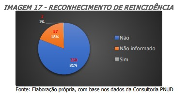

A busca pela proporcionalidade e pela razoabilidade do valor da multa começa na definição legal da base de cálculo, limitada às opções do faturamento no ramo de atividade empresarial em que se deu a infração ou ao faturamento total da empresa ou grupo, e se aprimora de forma definitiva na definição da alíquota, qual seja, a criteriosa análise das condições agravantes e atenuantes previstas no art. 45 da Lei nº 12.529/2011.

Chama atenção a afirmação contida na página 33 do documento de trabalho “TCC na Lei nº 12.529/11”<sup><sup>[2]</sup></sup>, de que somente em 4,15% dos TCCs firmados na vigência da Lei nº 12.529/11 a base de cálculo obedeceu a regra prescrita na lei:

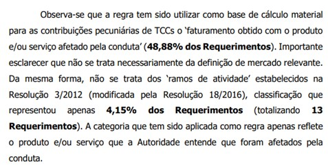

Há, portanto, claros sinais de alerta soando para as autoridades do Cade que o posicionamento desta Autarquia necessita de aprimoramento. Qualquer forma de flexibilização da base de cálculo deve ser uma exceção à regra legal e ainda resultar em valor pecuniário superior ao mínimo legal (§ 2º do art. 85 da Lei nº 12.529/11) e dissuasório. A subversão dessa lógica reduz o *enforcement* do Cade na tutela dos interesses protegidos pela Lei nº 12.529/11.

Na proposta de TCC em julgamento o valor da multa esperada da empresa constante no seu Anexo I corresponde a [**ACESSO RESTRITO AO CADE E À REQUERENTE]** do valor do faturamento bruto obtido no último exercício anterior à instauração do PA, no ramo de atividade empresarial em que ocorreu a infração [**ACESSO RESTRITO AO CADE E À REQUERENTE]**, valor que, embora superior ao valor da multa mínima prevista no inc. I do art. 37 da Lei nº 12.529/11, não se revela dissuasória e nem compatível com a gravidade da infração em apuração no PA nº 08012.007043/2010-79.

Inviável, portanto, a aceitação da proposta, por violação ao disposto no art. 85, § 14, c/c o art. 37, inc. I, da Lei nº 12.529/11, e no art. 186 e art. 187 do Ricade.

**b) Da contribuição pecuniária ao Fundo de Direitos Difusos prevista para a adesão de pessoas físicas**

Pelos termos da **Cláusula Quinta – Da Adesão de Pessoas Físicas**, item 5.4.1. e item 5.4.2. da proposta de Termo de Compromisso de Cessação (“TCC”) em julgamento, é facultada a adesão de pessoas físicas já identificadas nos autos ao TCC, mediante o recolhimento de contribuição pecuniária ao Fundo de Direitos Difusos (“FDD”) no valor de (i) [**ACESSO RESTRITO AO CADE E À REQUERENTE**] para “funcionários que ocuparam cargos de administrador em qualquer entidade integrante do grupo econômico da Compromissária na época dos fatos investigados” ou (ii) [**ACESSO RESTRITO AO CADE E À REQUERENTE**] na hipótese de funcionários que não ocuparam cargos de administrador, se a adesão ocorrer em até seis meses após a publicação da homologação do TCC no Diário Oficial da União (“DOU”).

*b.1) Da violação ao disposto no art. 85, § 14, da Lei nº 12.529/11, c/c o art. 187 do Ricade*

O valor da contribuição pecuniária para a adesão de funcionários que ocuparam cargos de administrador previsto no item 5.4.1. da proposta de TCC em julgamento consiste na repetição do valor da contribuição pecuniária da empresa Requerente, como se extrai da leitura dos subitens 3.1.1., 7.4., e do Anexo I e do Anexo II da proposta de TCC.

Vale esclarecer que é somente em razão da soma do valor da cláusula de escopo que o valor da contribuição pecuniária final da pessoa jurídica não corresponde ao valor de adesão da pessoa física administradora. Contudo, o valor é idêntico considerando tão somente o montante resultante do desconto sobre a multa esperada da empresa, valor que, de fato, corresponde à contribuição pecuniária da empresa.

A estipulação de contribuição pecuniária para administrador no mesmo valor da contribuição pecuniária da empresa em TCC é vedada ao Cade pelo disposto no art. 186 e art. 187 do Ricade[3], que encontra fundamento de legalidade no art. 85, § 14, da Lei nº 12.529/11. O referido dispositivo regimental estabelece que a contribuição pecuniária do administrador deve ser calculada a partir da multa esperada atribuída à pessoa física administradora que, por sua vez, deve ser calculada a partir da multa esperada da pessoa jurídica.

Nos termos do inc. III do art. 37 da Lei nº 12.529/11[4], é certo que a multa esperada do administrador não coincidirá com a multa esperada da empresa, pois aquela representa um percentual de 1% a 20% da multa aplicada à empresa, podendo ainda incidir um desconto de até 15% sobre esse valor no âmbito do Tribunal Administrativo, nos termos do art. 187 do Ricade.

Assim, enquanto o legislador tratou de definir o valor mínimo da contribuição pecuniária no texto da Lei nº 12.529/11, o Cade utilizou o seu poder regulamentar para definir o **valor máximo** da contribuição pecuniária ao FDD em TCC.

Em se tratando de administrador, o valor máximo da contribuição pecuniária corresponde ao valor obtido a partir da aplicação do desconto mínimo previsto no art. 186 ou no art. 187 do Ricade sobre o valor da maior multa esperada para o administrador, qual seja, 20% da maior multa aplicável à empresa que, por sua vez, equivale a 20% do seu faturamento bruto obtido no último exercício anterior à instauração do PA, no ramo de atividade empresarial em que ocorreu a infração, a qual nunca será inferior à vantagem auferida, quando for possível sua estimação, *ex vi* do disposto no art. 37, inc. I e inc. III, da Lei nº 12.529/11.

Por força do princípio da legalidade, é vedado ao Cade exigir contribuição pecuniária do administrador no mesmo valor da contribuição pecuniária da empresa em TCC sem antes alterar as normas do art. 186 e do art. 187 do Ricade, por meio de emenda regimental, a qual deverá atender ao quanto disposto no art. 230 e no art. 231 do Ricade, que exige, dentre outros requisitos, submissão da proposta de emenda regimental a consulta pública e elaboração de parecer pela Procuradoria Federal Especializada junto ao Cade, mormente em se tratando de uma expressão do poder punitivo estatal.

Assim, o subitem 5.4.1. do TCC contraria a norma prevista no art. 187 do Ricade, que encontra fundamento de legalidade no art. 85, § 14, da Lei nº 12.529/11, o que caracteriza óbice legal intransponível à aceitação da proposta de TCC em julgamento.

**II – ANÁLISE DOS REQUISITOS LEGAIS DISCRICIONÁRIOS (JUÍZO MOTIVADO DE CONVENIÊNCIA E OPORTUNIDADE)**

A proposta de TCC em julgamento contraria disposições legais e regimentais, quais sejam, o art. 37, inc. I e inc. III, art. 85, § 2º e § 14, todos da Lei nº 12.529/11, e o art. 187 do Ricade, o que, por si sós, vedam o exercício do juízo motivado de conveniência e oportunidade do Cade para aceitação da proposta.

Pelo princípio da eventualidade, me permito expor o meu posicionamento sobre o mérito da proposta, e com a finalidade de *instruir o público sobre as formas de infração da ordem econômica*, conforme competência do Plenário deste Tribunal Administrativo prevista no inc. XIV do art. 9º da Lei nº 12.529/11.

**a) Da contribuição pecuniária ao Fundo de Direitos Difusos (“FDD”) prevista para empregados sem cargo de administrador**

Oportunamente, reitero meu entendimento quanto à impossibilidade jurídica da responsabilização de pessoas físicas não administradoras por infrações contra a ordem econômica perante a Lei nº 12.529/2011, conforme já me manifestei em outras oportunidades[5]. Contudo, considerando que a jurisprudência majoritária deste Conselho atualmente indica que tais pessoas podem ser responsabilizadas administrativamente com fundamento no inc. II do art. 37 da Lei nº 12.529/2011, entendo que seja importante tecer considerações a respeito do juízo de conveniência e oportunidade em celebrar o presente TCC, conforme exigido pelo *caput* do art. 85 da Lei nº 12.529/2011, ainda que esse juízo também recaia sobre a situação de pessoas físicas não administradoras.

Em primeiro lugar, chama atenção o baixo valor dissuasório estabelecido para a adesão de pessoas físicas não administradoras, que, para fins de referência, é inferior ao valor mínimo legal para pessoas nessa qualidade investigadas por conduta de cartel, nos termos do § 2º do art. 85 da Lei nº 12.529/2011, qual seja, R$ 50.000,00.

Muito embora compreenda que o mínimo legal, no caso concreto, corresponde a 6.000 UFIR (inc. III do art. 23 da Lei nº 8.884/94), haja vista que a proposta de TCC em julgamento trata de fatos ocorridos sob a vigência da Lei nº 8.884/94, que contempla previsão de multas mais benéficas para pessoas físicas não administradoras em comparação com os dispositivos da Lei nº 12.529/2011, ressalto que o valor da contribuição pecuniária referente à adesão de pessoas físicas não administradoras não é conveniente e nem oportuna.

A esse respeito, dispõe o Guia de TCC do Cade na sua página 43: “(...) mesmo para casos de infração ocorrida na vigência da Lei nº 8.884/1994, o Cade não considera razoável negociar um TCC em valor inferior ao patamar de R$ 50.000,00 (cinquenta mil reais)”.

Também recordo a competente defesa recentemente feita pelo MPF perante o Cade em memoriais (SEI 0846905) no PA nº 08700.000066/2016-90, em reforço à jurisprudência deste Tribunal Administrativo quanto à aplicação de multa em valor nunca inferior a R$ 50.000,00 para funcionários que não ocupam cargos de administrador em empresas envolvidas na prática de infração contra a ordem econômica.

Assim, embora entenda que o valor estabelecido para adesão de pessoas físicas não administradoras no presente TCC seja superior ao mínimo legal exigido, existem diversos alertas no sentido de que valores nesse patamar não apresentam o efeito dissuasório esperado e que sequer possam ser considerados razoáveis para fins de conveniência e oportunidade da Administração Pública.

**b) Demais considerações sobre a conveniência e oportunidade da proposta de TCC para o Cade**

O Tribunal de Contas da União (“TCU”) apura no procedimento autuado sob a denominação de TC 017.012/2020-1, denúncia do Ministério Público de Contas de supostas violações ao comando do art. 37, inc. I, e art. 85, § 2º, todos da Lei nº 12.529/11, em TCCs aprovados pelo Cade para o encerramento de investigações de ilícitos anticoncorrenciais em diversas licitações abrangidas pelo escopo da operação Lava Jato.

Segundo a denúncia, é possível ter havido a aceitação de TCCs pelo Cade com previsões para o recolhimento de contribuições pecuniárias ao FDD em valores inferiores ao mínimo legal para a contribuição de empresas, obtido pela interpretação conjunta do art. 85, § 2º, com a parte final do art. 37, inc. I, da Lei nº 12.529/11.

Na apuração em curso perante o TCU, o valor mínimo legal da contribuição pecuniária a empresas supostamente não observado pelo Cade corresponde ao valor da vantagem auferida estimada. Nesse contexto, considerando o baixo valor da contribuição pecuniária da empresa e do funcionário sem cargo de administrador contidas na proposta de TCC em julgamento, observo diversos inconvenientes contrários à sua aceitação, sem motivo ou benefício que justifique o Cade atraí-los para si.

Em um exercício de análise sobre o juízo de conveniência e oportunidade da Administração Pública no julgamento da proposta de TCC em análise, entendo haver mais prejuízos ao Cade na implementação da política pública de defesa dos interesses tutelados na Lei nº 12.529/11 com a aceitação da proposta de TCC em julgamento do que potenciais benefícios, ademais por se tratar TCC em autos de PA já remetidos ao Tribunal Administrativo para julgamento, após o encerramento da fase instrutória de competência da Superintendência-Geral do Cade (SG”).

Na mesma esteira, não reputo existente conveniência e oportunidade do lado da Administração Pública na aceitação da proposta de TCC em julgamento, cuja multa esperada da empresa foi calculada tomando como base de cálculo o faturamento bruto obtido na comercialização do **produto afetado,** pelas razões expostas no item I, “a”, deste voto. Também não reputo existente conveniência e oportunidade na criação de precedente na jurisprudência do Cade em desrespeito às normas do art. 186 e art. 187 do Ricade, extrapolando o limite máximo previsto para a contribuição pecuniária do administrador, ao mesmo tempo em que reduz o valor da contribuição pecuniária do empregado sem cargo de administrador para baixo do valor mínimo recomendado no Guia de TCC do Cade.

Importa ressaltar que não nego a importância da política de TCCs para a realização do princípio da eficiência administrativa, previsto no *caput* do art. 37 da Constituição Federal e no *caput* do art. 2º da Lei nº 9.874/99, proporcionando economia processual a esta Autarquia ora por meio do encerramento de investigações antes de apurada a autoria e a materialidade da infração à ordem econômica, ora por meio da obtenção de elementos probatórios a um custo mais baixo de tempo e de investimentos por parte da Administração Pública.

Contudo, a política de TCCs do Cade deve evoluir, e reconheço a existência de sinais claros direcionados a esta Autarquia nesta direção.

Os sinais documentais deste alerta estão consubstanciados no procedimento TC 017.012/2020-1, em curso perante o TCU, e no documento de trabalho “TCC na Lei nº 12.529/11”, mencionado no item I, “a”, deste voto, no qual chama atenção a conclusão contida na sua página 33 de que **somente em 4,15% dos TCCs firmados na vigência da Lei nº 12.529/11 a base de cálculo obedeceu a regra prescrita na lei.**

Estes sinais de alerta vindos de terceiros externos ao Cade devem impor uma postura reflexiva a este Tribunal Administrativo neste momento.

Em complemento às razões expostas no item I, “a”, deste voto, não reputo válidos os argumentos de busca por “proporcionalidade e razoabilidade” verificados na jurisprudência do Cade para fundamentar a “flexibilização legal” da base de cálculo prevista no inc. I e no inc. II do art. 37 da Lei nº 12.529/11, que deve ser observada tanto no julgamento de PAs, como no cálculo de contribuição pecuniária ao FDD em TCCs, por força do disposto no art. 85, § 2º e § 14, da Lei nº 12.529/11, e no art. 186 e art. 187 do Ricade.

A busca pela necessária proporcionalidade e a razoabilidade da pena de multa prevista no art. 37 da Lei nº 12.529/11 e da contribuição pecuniária ao FDD prevista no art. 85, § 2º, da Lei nº 12.529/11, deve ser feita por meio dos instrumentos previstos na lei. A proporcionalidade e a razoabilidade da pena de multa ou da contribuição pecuniária são produtos necessários e obrigatórios do resultado obtido pelo Cade na aplicação dos comandos previstos no art. 37 e no art. 45 da Lei nº 12.529/11, e no art. 186 e art. 187 do Ricade, na hipótese de contribuição pecuniária.

Em outras palavras, a proporcionalidade e a razoabilidade devem decorrer de uma operação de **subsunção simples**, consistente na incidência de uma alíquota de 0,1% a até 20%, definida por meio de decisão fundamentada que aborde, obrigatoriamente, as circunstâncias descritas nos incisos I a VIII do art. 45 da Lei nº 12.529/11, sobre o valor do “faturamento bruto da empresa, grupo ou conglomerado obtido, no último exercício anterior à instauração do processo administrativo, no ramo de atividade empresarial em que ocorreu a infração” (inc. I do art. 37 da Lei nº 12.529/11), ou do “faturamento total da empresa ou grupo de empresas, quando (o Cade) não dispuser do valor do faturamento no ramo de atividade empresarial em que ocorreu a infração (...) ou quando este for apresentado de forma incompleta e/ou não demonstrado de forma inequívoca e idônea” (§ 2º do art. 37 da Lei nº 12.529/11).

Em que pese a lei ser clara e de fácil cumprimento, observa-se na jurisprudência do Cade dispêndio de recursos públicos escassos, consistentes na mão de obra de técnicos e dirigentes da SG, do DEE e do Tribunal Administrativo para a definição de bases de cálculo distintas daquela prevista na lei, sob os argumentos de se obter uma base de cálculo proporcional e razoável, **quando a medida de proporcionalidade e de razoabilidade da base de cálculo foi previamente definida pelo legislador, e se constitui em valor da sociedade, segundo o grau de importância que elegeu para a defesa dos interesses protegidos pela Lei nº 12.529/11, do qual o Cade não possui competência legal para dispor de modo diverso.**

A “flexibilização” da definição de base de cálculo contida no inc. I do art. 37 da Lei nº 12.529/11 por autoridade do Poder Executivo sob o fundamento de busca por proporcionalidade e razoabilidade subverte a ordem jurídica, pois se afasta do dever de obediência à norma da presunção de constitucionalidade das leis. Somente o Poder Judiciário possui competência constitucional para afastar a base de cálculo definida no inc. I do art. 37 da Lei nº 12.529/11, em processo objetivo no controle concentrado de constitucionalidade ou em processo subjetivo no controle difuso de constitucionalidade, que identifique o expresso texto da Constituição Federal vulnerado pela redação constante na lei.

É somente nestas condições, por meio de decisão judicial que poderá adotar como fundamentos o princípio da proporcionalidade ou da razoabilidade, ou outro fundamento válido, que a base de cálculo pode ser flexibilizada sem alteração do texto da Lei nº 12.529/11.

Registro que considero os estudos realizados pela SG, pelo DEE e pelo Tribunal Administrativo em relação a exercícios para a obtenção de valores de faturamento bruto obtidos no mercado afetado e com o produto ou serviço afetado válidos e de extrema importância para este Tribunal Administrativo, **porém o *topos* legal de utilização destas informações é na etapa de definição fundamentada da alíquota aplicável, especificamente no lugar da fundamentação para a valoração da circunstância prevista no inc. III do art. 45 da Lei nº 12.529/11, qual seja, “a vantagem auferida ou pretendida pelo infrator”.**

E a correta alocação **legal** da interpretação dos resultados das pesquisas sobre o faturamento bruto obtido no mercado afetado ou com o produto ou serviço afetado tem grande impacto na implementação da política pública de defesa dos interesses protegidos pela Lei nº 12.529/11. A alteração na alocação correta deste **fator**, definido na Lei nº 12.529/11 como componente da definição da alíquota para obtenção do valor da pena de multa, para o lugar do **fator** base de cálculo, **altera o resultado, identificado com a correta proteção dos valores tutelados pela Lei nº 12.529/11.**

O julgamento da proposta de TCC em tela é emblemático desta situação. Não é difícil verificar que todo o debate em torno deste julgamento decorre da tentativa de acomodação do fato de que, ao se utilizar o faturamento da empresa com o produto afetado como base de cálculo, chegou-se a um valor de multa esperada incapaz de se constituir em uma multa dissuasória, além de proporcional e razoável quando comparada com o valor do faturamento bruto obtido pela empresa no mesmo exercício, no ramo de atividade empresarial em que ocorreu a infração, devidamente previsto no item 97 da Resolução Cade nº 3/2012, mesmo após a incidência da alíquota máxima de 20%.

Para além desta situação, que por si só justifica, no meu entendimento, a rejeição da proposta de TCC em julgamento, ainda mais em se tratando de apuração de infração constituída pela prática dos atos previstos no inc. I e no inc. II do § 3º do art. 36 da Lei nº 12.529/11 (cartel, ilícito por objeto), o valor alcançado para a multa esperada da empresa antes da correção pela Selic foi inferior ao valor da multa mínima esperada para o seu funcionário sem cargo de administrador já identificado no PA, qual seja, R$ 50.000,00, nos termos da jurisprudência deste Tribunal Administrativo (inc. II do art. 37 da Lei nº 12.529/11). Após a correção da multa esperada da empresa pela Selic, o valor obtido foi [**ACESSO RESTRITO AO CADE E À REQUERENTE]**.

Ato contínuo, o valor da multa esperada para o administrador da Requerente, se respeitado o comando do art. 187 do Ricade, que encontra suporte de validade na norma do § 14 do art. 85 da Lei nº 12.529/11, seria de, no máximo, [**ACESSO RESTRITO AO CADE E À REQUERENTE]**, isto é, 20% do valor da multa esperada da empresa.

Diante do evidente paradoxo verificado, consistente na situação de o valor da multa esperada para o funcionário sem cargo de administrador ser (i) superior ao valor da multa esperada da empresa antes da atualização pela Selic e [**ACESSO RESTRITO AO CADE E À REQUERENTE]**, e ao mesmo tempo (ii) quase [**ACESSO RESTRITO AO CADE E À REQUERENTE]** vezes o valor da multa esperada do administrador, a proposta de TCC em julgamento oferece o seguinte caminho para ser aprovado por este Tribunal Administrativo:

Reduzir o valor da contribuição pecuniária do empregado sem cargo de administrador para valor inferior ao mínimo recomendado no Guia de TCC do Cade; e

Violar o disposto no art. 186 e no art. 187 do Ricade, e no § 14 do art. 85 da Lei nº 12.529/11, para aumentar o valor da contribuição pecuniária do administrador em [**ACESSO RESTRITO AO CADE E À REQUERENTE]** vezes o valor da maior contribuição admitida na legislação do compromisso de cessação.

Admitir a formação de tal precedente por este Tribunal Administrativo é inverter o postulado de direito público da supremacia do interesse público sobre o interesse privado, mormente quando nenhum paradoxo seria verificado no caso em análise se a base de cálculo da multa esperada da empresa coincidisse com a definição contida no inc. I do art. 37 da Lei nº 12.529/11 e a correspondente alíquota fosse calibrada a partir de uma criteriosa análise de cada uma das condições dispostas nos incisos do art. 45 da mesma lei.

O TCC, na forma como proposto, vai ao encontro dos interesses privados da empresa e das pessoas físicas que o propuseram, e vai de encontro com o interesse público na tutela dos valores protegidos pela Lei nº 12.529/11.

A incongruência entre, de um lado, a (i) proposta de TCC em julgamento, os TCCs estudados no documento de trabalho da Presidência do Cade, nominado “TCC na Lei nº 12.529/11”, e, de outro lado, (ii) os comandos legais previstos no art. 85, § 14, e no art. 37, inc. I e inc. III, todos da Lei nº 12.529/11, e no art. 186 e no art. 187 do Ricade, **expõe a oportunidade de uma pausa para a reflexão sobre o conceito de interesse público na ponderação sobre o juízo de conveniência e oportunidade do Cade na tomada de compromisso de cessação.**

Além de reduzir a eficácia das ações de repressão contra infrações à ordem econômica para níveis abaixo daquele exigido pela lei, a incongruência acima identificada torna a jurisprudência do Cade instável e imprevisível.

A propósito (i) de os valores das penas de multa aplicadas pelo Cade serem historicamente baixos e (ii) da insegurança jurídica presente e instalada na política de defesa da concorrência pela falta de rigor técnico na definição dos valores das penas de multa pelo Cade, a OCDE assim registrou no documento *Revisão por Pares da OCDE sobre Legislação e Política de Concorrência: Brasil*, de 2019:[6]

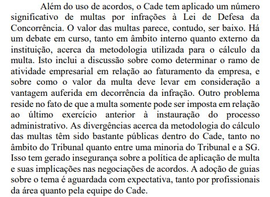

Em termos de aprimoramento da política pública de defesa da concorrência pelo Cade, entendo, ainda, que a aprovação e consequente assinatura do TCC em julgamento contraria o interesse público na medida em que o PA nº 08012.007043/2010-79, que se pretende arquivar em relação à requente e seus funcionários com a aceitação e cumprimento dos termos da proposta de TCC em julgamento, reúne a presença de diversos elementos a respeito da aplicação da Lei nº 12.529/11 sobre os quais este Tribunal Administrativo recentemente tem se debruçado, e cujos debates merecem aprofundamento, não sendo desejável, em exercício de juízo de conveniência e oportunidade, que este Tribunal Administrativo deixe de se pronunciar sobre a aplicação da Lei nº 12.529/11 em um caso com estes contornos, e já maduro para julgamento pelo Plenário.

DisposiTIVO

Ante o exposto, voto pela rejeição da proposta de TCC.

É o voto.

Brasília, 19 de abril de 2021

(assinado eletronicamente)

SÉRGIO COSTA RAVAGNANI

Conselheiro

[1] https://cdn.cade.gov.br/Portal/centrais-de-conteudo/publicacoes/TCC%20na%20Lei%20n%C2%BA%2012.52911/TCC%20na%20Lei%20n%C2%BA%2012.529-11.pdf, acessado em 29/03/2021.

[2] Idem.

[3] Art. 187. A análise da contribuição pecuniária nas propostas de TCC realizadas nos termos do art. 181 em investigações de acordo, combinação, manipulação ou ajuste entre concorrentes, levará em consideração o estado do processo administrativo, observado, quando possível de estimação, **a redução percentual máxima de 15% da multa esperada ao Representado.**

[4] Art. 37. A prática de infração da ordem econômica sujeita os responsáveis às seguintes penas:

III - no caso de administrador, direta ou indiretamente responsável pela infração cometida, quando comprovada a sua culpa ou dolo, multa de 1% (um por cento) a 20% (vinte por cento) daquela aplicada à empresa, no caso previsto no inciso I do caput deste artigo, ou às pessoas jurídicas ou entidades, nos casos previstos no inciso II do caput deste artigo.

[5] PA 08012.005324/2012-59; PA 08700.000066/2016-90 e 08700.006065/2017-30.

[6] https://www.oecd.org/competition/oecd-peer-reviews-of-competition-law-and-policy-brazil-2019.htm, pág. 15, acesso em 11.4.2021.

|  | Documento assinado eletronicamente por **Sérgio Costa Ravagnani**, **Conselheiro**, em 19/04/2021, às 18:04, conforme horário oficial de Brasília e Resolução Cade nº 11, de 02 de dezembro de 2014. |
| --- | --- |

|  | A autenticidade deste documento pode ser conferida no site sei.cade.gov.br/autentica, informando o código verificador **0893793** e o código CRC **802A4819**. |
| --- | --- |

| **Referência:** Processo nº 08700.005718/2020-69 | SEI nº 0893793 |
| --- | --- |